## Kate Hoff Shutta

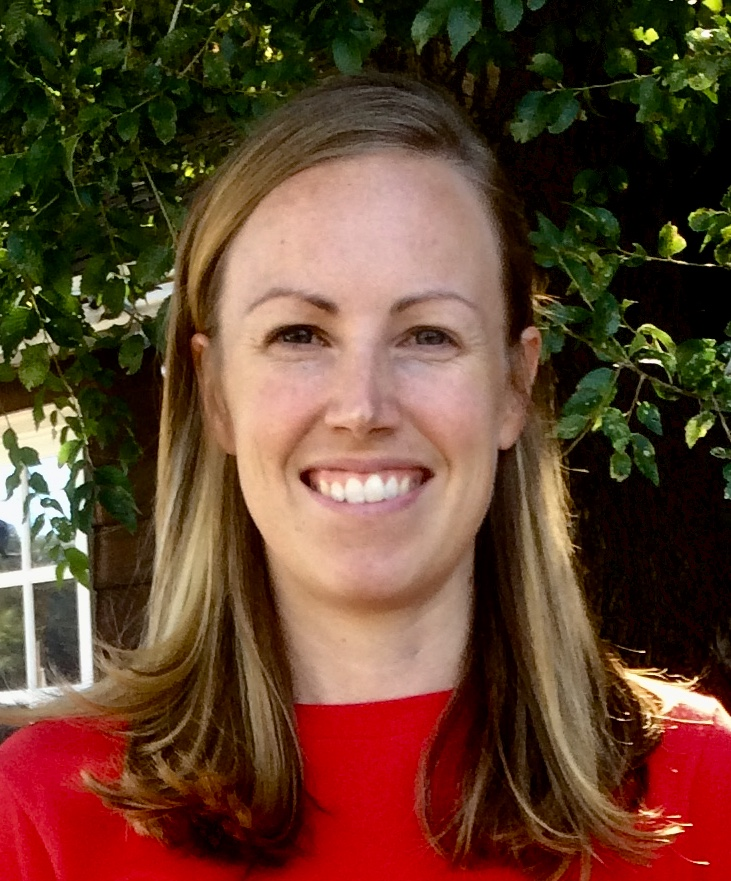

### About

I am a graduate student pursuing a Ph.D. in Biostatistics at UMass - Amherst.

### Research

My interest is in the development and assessment of network methods for high-dimensional datasets, with the goal of contributing to advances in public health.

I currently work as a graduate student research assistant on the NIH grant “Development and application of a metabolomics profile of chronic distress to cardiometabolic risk” (NIH R01 AG051600 01A1, Co-PIs: Susan E. Hankinson, Sc.D., Laura D. Kubzansky, Ph.D.; Co-investigator: Raji Balasubramanian, Sc.D.). This study evaluates metabolomics profiles associated with chronic distress among women enrolled in the Nurses Health Study and the Women’s Health Initiative.

I am also a graduate student research assistant on the NIH grant "Network Models for Metabolomics" (NIH R01 LM013444-01, Co-PIs: Raji Balasubramanian, Sc.D., Denise Scholtens, Ph.D.). As part of this work, I am developing methods for network estimation and differential network analysis with applications to metabolomics datasets.

### Contact

Email: no kshutta robot at emails umass please! dot edu

Department of Biostatistics and Epidemiology  
UMass Amherst School of Public Health and Health Sciences  
010 Arnold House  
715 North Pleasant Street  
Amherst, MA 01003